# R Notebook

After reading an artivle on the subjectivity of the USDA’s rankings of American counties by scenery and climate, the author hypothesised that counties ranked lower on this scale would experience less severe impacts from the warming climate. This was based on the USDA’s criteria for the ranking, which favoured warmer counties located by the sea or near mountains–both geographic features correlated with natural disasters driven by climat change. To test this hypothesis, the author merged the dataset provided by the USDA with one gathered by the journalism nonprofit ProPublica. ProPublica, in coordination with the Rhodium Group, scored counties based on increases in the following metrics:

1. Wet bulb temperature (mix of heat and humidity)
2. Overall heat
3. Loss of crop yield
4. Sea level rise
5. Very large fires
6. Overall economic damage.

The scores for these metrics were added to create an overall liveability metric, and a regression performed against the counties’ subjective attractiveness.

```
* ...
```

```
Call:
lm(formula = Liveability ~ Attractiveness.USDA, data = self$df)

Residuals:
     Min       1Q   Median       3Q      Max
-14.7215  -4.1100  -0.6876   3.9188  20.5890

Coefficients:
                    Estimate Std. Error t value Pr(>|t|)
(Intercept)         20.81357    0.09725  214.01   <2e-16 ***
Attractiveness.USDA  0.35990    0.04269    8.43   <2e-16 ***
---
Signif. codes:  0 ‘***’ 0.001 ‘**’ 0.01 ‘*’ 0.05 ‘.’ 0.1 ‘ ’ 1

Residual standard error: 5.419 on 3104 degrees of freedom
  (7 observations deleted due to missingness)
Multiple R-squared:  0.02238,   Adjusted R-squared:  0.02207
F-statistic: 71.07 on 1 and 3104 DF,  p-value: < 2.2e-16
```

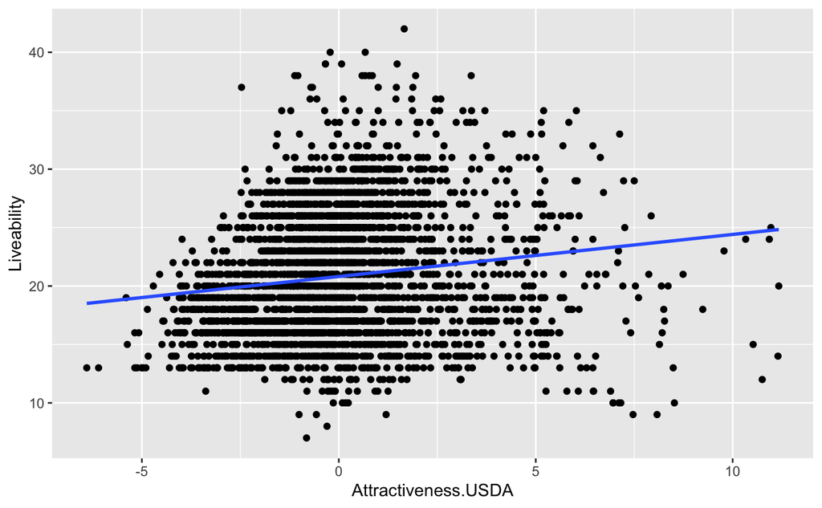

The hypothesis was not born out. There was a weak positive correlation, suggesting that more attractive counties were slightly more like to experience economic damage. This may be due to variance in the types of damage, so that less attractive counties had higher risk for features not correlated with attractiveness. To explore this possibility, the correlation of attractiveness with each of the variables making up overall climate risk, was calculated.

```
* ...
```

```
                        [,1]
Heat              0.18193631
Wet.Bulb         -0.22886514
Farm.Crop.Yields -0.08476726
Very.Large.Fires  0.50741478
Economic.Damages  0.08028562
```

The results somewhat bore this hypothesis out: more attractive counties were more likely to experience heat and fire-related damage, while less attractive counties were more at risk from wet bulb temperature increases (meaning higher and more dangerous humidity) and loss of crop yields. Thus, a different picture emerges than that which was originally hypothesised: less attractive counties, most of them in the center of the country, face different challenges from climate change–but not necessarily less severe ones.